# midterm

Jonathan Cheon

10/15/2019

Loading in libraries we are going to use.

```r
suppressMessages(library(tidyverse))
suppressMessages(library(dplyr))
```

Reading in sales.csv and doing some initial cleaning.

```r
#reading in sales.csv file
sales <- read_csv("sales.csv")
#changing column name to appropriate name
colnames(sales)[colnames(sales)=="category of inventory goods"] <- "type_of_goods"

#transforming columns to single column of sale_year for cleaner data.
sales <- gather(sales, "sale_year", "sales_per_month", 2:23)

#separating the month-year format into separate columns
sales <- separate(sales, sale_year, into = c("month", "year"), sep = "-")
```

Reading in register.csv and doing some cleaning.

```r
#reading in register.csv while replacing '--' with NA values
register <- read_csv("register.csv", na = "--")
#changing column names to appropriate ones.
colnames(register)[colnames(register)=="is the customer a student/faculty/staff (0) or unaffiliated (1)"] <- "affiliate"
colnames(register)[colnames(register)=="customer id"] <- "customer_id"
colnames(register)[colnames(register)=="contact preference"] <- "contact_preference"
colnames(register)[colnames(register)=="preferred customer discount"] <- "preferred_discount"

#turning binary values to TRUE and FALSE
register$affiliate <- as.logical(as.integer(register$affiliate))

#making contact_preference and charge categorical variables
levels(register$contact_preference <- as.factor(register$contact_preference))
```

```
## [1] "email" "fax"   "mail"
```

```r
levels(register$charge <- as.factor(register$charge))
```

```
## [1] "cost" "tax"
```

Making separate table for just item related variables with register set.

```r
item_table <- tibble(purchase=register$purchase,
                     item=register$item,
                     charge=register$charge,
                     price=register$price,
                     customer_id=register$customer_id,
                     receipt=register$receipt
                     )

#making item's variable into categorical variable
levels(item_table$item <- as.factor(item_table$item))
```

```
## [1] "2028"    "4011"    "396941"  "519880"  "528028"  "781941"  "4251550"
## [8] "5888032"
```

Creating new table for customer related data from register set.

```r
customer_table <- tibble(customer_id=register$customer_id,
                         contact_preference=register$contact_preference,
                         newsletter=register$newsletter,
                         sales=register$sales,
                         preferred_discount=register$preferred_discount,
                         affiliate=register$affiliate
                         )

#deleting duplicate rows with same data.
customer_table <- distinct(customer_table)
```

Graph to display total sales of each type of good while distinguishing by year. THis graph is useful because it shows the highest revenue producing type of good. In this case, we can see that textbook is the highest revenue producing item. Health, beauty, and fitness category is the lowest revenue.

```r
x <- sales %>%
  group_by(type_of_goods, year) %>%
  select(sales_per_month) %>%
  summarise(
    revenue = sum(sales_per_month, na.rm = TRUE)
  )
```

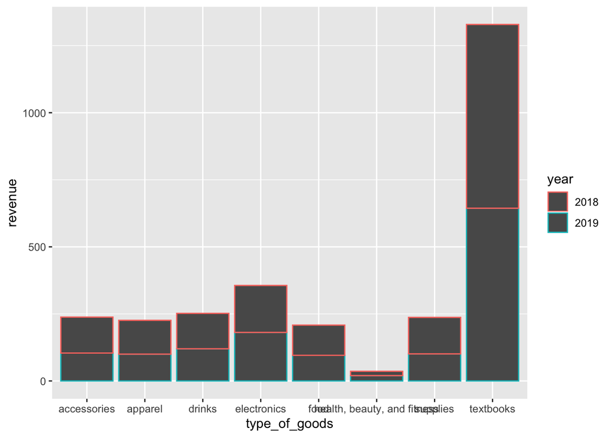

```r
ggplot(x, aes(type_of_goods, revenue, color = year)) +
  geom_bar(stat = "identity")
```

This graph shows us which single item was the highest producing revenue. Though this graph shows by item id, if we had the data to tell us what these item ids match up with, we could see which single item produces the highest revenue. In this case, we can see item 781941 is the best selling item.

```r
x <- item_table %>%
  group_by(item) %>%
  select(price) %>%
  summarise(
    revenue = sum(price, na.rm=TRUE)
  )
```

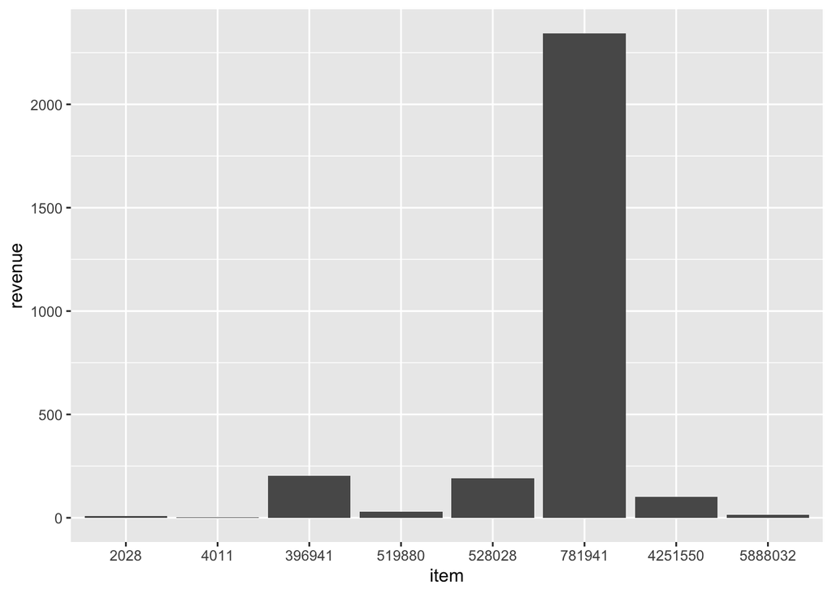

```r
ggplot(x, aes(item, revenue)) +
  geom_bar(stat = "identity")
```